# Class Stan Examples

STAT 341

2023-03-29

# Setup

In this document, I’m displaying the setup chunk to clarify which R packages are being used.

```r
library(tidyverse)
library(ggformula)
library(rethinking)
library(rstan)
library(CalvinBayes)
library(tidybayes)
library(bayesplot)
knitr::opts_chunk$set(echo = TRUE,
                      error = TRUE,
                      fig.width = 7,
                      fig.height = 4)

theme_set(theme_minimal(base_size = 16))
```

# Simple Normal Fit

Fit a normal distribution to the cell-phone-use-at-work data.

## Read in Phone Data

```r
phone_data  <- read_csv('https://sldr.netlify.app/data/phone_boredom.csv',
                        show_col_types = FALSE)

phone_data <- phone_data |>
  select(boredomS, fatigueS, fomo_scaled, total_b20S) |>
  rename(phone_useS = total_b20S) |>
  drop_na()
```

## Original `quap()` model

(for comparison)

```r
quap_mod <- quap(
  flist = alist(
    boredomS ~ dnorm(mu, sigma),
    mu <- dnorm(0, 0.25),
    sigma ~ dnorm(1, 1)
  ),
  data = phone_data)

# quick peek at quap results for later comparison
precis(quap_mod)
```

```
##             mean          sd        5.5%      94.5%
## mu    0.02201829 0.012896399 0.001407351 0.04262922
## sigma 0.49308958 0.009131723 0.478495327 0.50768384
```

```r
# prep data for use with stan
stan_phone_data <- compose_data(phone_data)

stan_phone_norm <- '
data {
  int<lower=1> n;         // number of observations
  vector[n] phone_useS;    // response

}
parameters {
  real<lower=0> sigma;     // std of response, single continuous value
  real mu;
}
model {
  mu ~ normal(0, 0.25);             // prior for mu
  // was: normal(120, 120) why did I change it?
  sigma ~ normal(1, 1);             // prior for sigma
  phone_useS ~ normal(mu, sigma);      // defining likelihood in terms of mus and sigma
}
'

boredom_model <- stan(model_code = stan_phone_norm,
                      data = stan_phone_data,
                      # suppress some screen printout
                      refresh = 0)
```

[output not shown]

[output not shown]

```r
boredom_model
```

```
## Inference for Stan model: anon_model.
## 4 chains, each with iter=2000; warmup=1000; thin=1;
## post-warmup draws per chain=1000, total post-warmup draws=4000.
##
##         mean se_mean   sd   2.5%    25%    50%    75%  97.5% n_eff Rhat
## sigma   0.49    0.00 0.01   0.47   0.48   0.49   0.49   0.50  3239    1
## mu      0.00    0.00 0.01  -0.03  -0.01   0.00   0.01   0.02  3737    1
## lp__  321.92    0.02 1.00 319.22 321.51 322.21 322.64 322.92  1764    1
##
## Samples were drawn using NUTS(diag_e) at Mon Jun  3 13:25:13 2024.
## For each parameter, n_eff is a crude measure of effective sample size,
## and Rhat is the potential scale reduction factor on split chains (at
## convergence, Rhat=1).
```

## Diagnostics

### `n_eff`

```r
boredom_model2 <- stan(model_code = stan_phone_norm,
                      data = stan_phone_data,
                      iter = 2000,
                      warmup = 1000,
                      refresh = 0)
```

[output not shown]

[output not shown]

[output not shown]

[output not shown]

```r
boredom_model2
```

```
## Inference for Stan model: anon_model.
## 4 chains, each with iter=2000; warmup=1000; thin=1;
## post-warmup draws per chain=1000, total post-warmup draws=4000.
##
##         mean se_mean   sd   2.5%    25%    50%    75%  97.5% n_eff Rhat
## sigma   0.49    0.00 0.01   0.47   0.48   0.49   0.49   0.50  3684    1
## mu      0.00    0.00 0.01  -0.03  -0.01   0.00   0.01   0.02  3958    1
## lp__  321.94    0.02 1.00 319.42 321.53 322.24 322.67 322.93  1777    1
##
## Samples were drawn using NUTS(diag_e) at Mon Jun  3 13:25:13 2024.
## For each parameter, n_eff is a crude measure of effective sample size,
## and Rhat is the potential scale reduction factor on split chains (at
## convergence, Rhat=1).
```

A bit better but not much?

### $\hat{R}$

- We observe: all values are 1
- Action needed? Nope, all good

## Warning: Divergent Transitions?

- We observe: Nope, no warnings.
- Action needed? No.

### Trace Plot

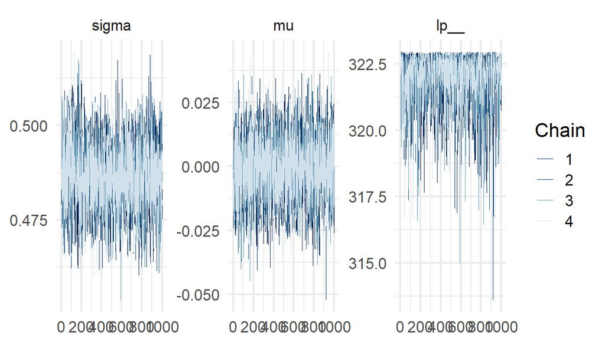

```r
bayesplot::mcmc_trace(boredom_model)
```

### Rank Trace Plot

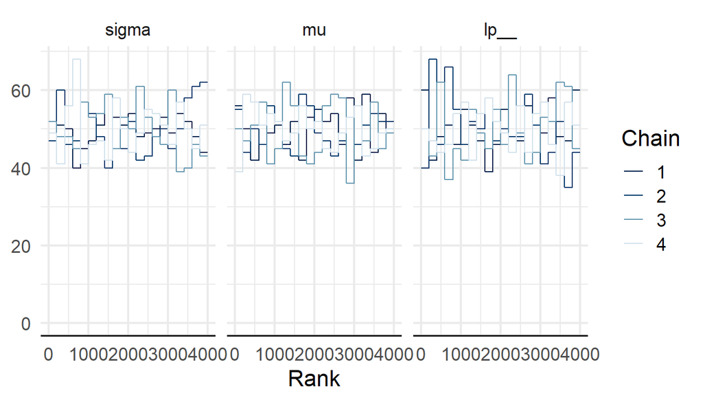

```r
bayesplot::mcmc_rank_overlay(boredom_model)
```

# Linear Regression with Quantitative Predictor

Fit a simple linear model to the `foxes` data.

## Prepare Data

```r
# data is from rethinking package
data('foxes')
foxes <- foxes |>
  drop_na(avgfood)

# compose data for use in stan
stan_fox_data <- compose_data(foxes)
```

## Stan fit

- *Note: `quap()` fit not shown this time - you could fit it as an exercise. Author says that the posteriors are similar for `quap` and Stan.*

```r
stan_fox_regression <- '
data {
  int<lower=1> n;     // number of observations
  vector[n] weight;    // response
  vector[n] avgfood;     // predictor
}
parameters {
  real<lower=0> sigma; // std of response, single continuous value
  real a; // intercept
  real b; // slope
}
model {
  vector[n] mu; // vector of n values: expected weight for each observation
  for (i in 1:n) { // loop over the n cases in the dataset to estimate mu_i values
    mu[i] = a + b * avgfood[i];
  }
  a ~ normal(3.5, 1); // prior for intercept
  b ~ normal(5, 1); // prior forslope
  // this is probably not the same prior as used for quap()!
  sigma ~ exponential(1); // prior for sigma
  weight ~ normal(mu, sigma); // defining likelihood in terms of mus and sigma
}
'

# fit the model defined above to the stan_data
foxes_model <- stan(model_code = stan_fox_regression,
                    data = stan_fox_data,
                    chains = 4,
                    # suppress some screen printout
                    refresh = 0)
```

[output not shown]

[output not shown]

[output not shown]

[output not shown]

[output not shown]

[output not shown]

```r
foxes_model
```

```
## Inference for Stan model: anon_model.
## 4 chains, each with iter=2000; warmup=1000; thin=1;
## post-warmup draws per chain=1000, total post-warmup draws=4000.
##
##         mean se_mean   sd   2.5%    25%    50%    75%  97.5% n_eff Rhat
## sigma   1.22    0.00 0.08   1.07   1.16   1.22   1.28   1.39  1627    1
## a       3.66    0.01 0.38   2.90   3.41   3.67   3.92   4.40  1255    1
## b       1.15    0.01 0.49   0.19   0.82   1.15   1.47   2.13  1273    1
## lp__  -89.73    0.03 1.23 -92.85 -90.30 -89.41 -88.84 -88.30  1353    1
##
## Samples were drawn using NUTS(diag_e) at Mon Jun  3 13:25:54 2024.
## For each parameter, n_eff is a crude measure of effective sample size,
## and Rhat is the potential scale reduction factor on split chains (at
## convergence, Rhat=1).
```

## Diagnostics

### `n_eff`

- We observe: It’s quite a bit smaller than the number of samples
- Action needed? Try increasing `warmup`

### $\hat{R}$

- We observe: All 1s
- Action needed? No action, all ok

## Warning: Divergent Transitions?

- We observe: Nope
- Action needed? Nope

### Trace Plot

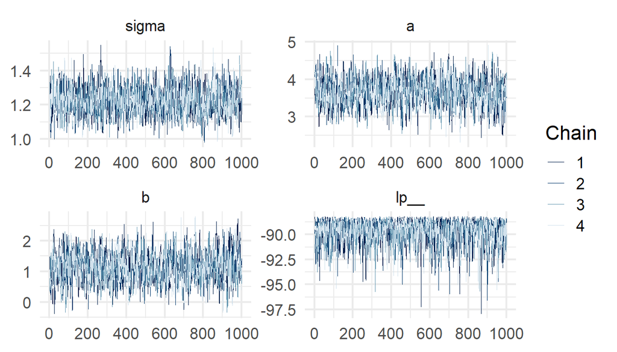

```r
bayesplot::mcmc_trace(foxes_model)
```

- We observe: Looks like pretty good mixing
- Action needed? Probably no

### Rank Trace Plot

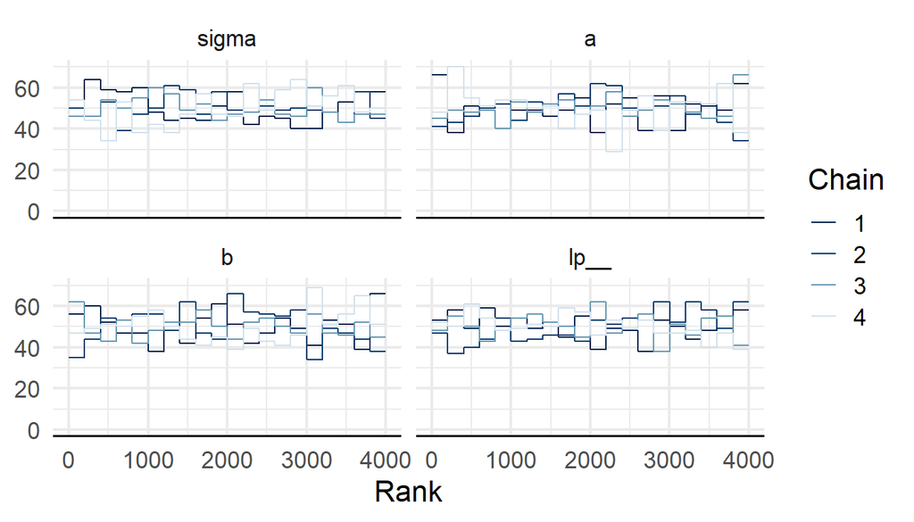

```r
bayesplot::mcmc_rank_overlay(foxes_model)
```

- We observe: Not too bad
- Action needed? Maybe no, but could add or lengthen chains

# Regression with Multiple Quantitative Predictors

This is an analysis of the data on bug diversity in houses and how it relates to residents’ socioeconomic status.

## Read in Data

```r
bugs <- read_csv('https://sldr.netlify.app/data/house_bugs.csv',
                 show_col_types = FALSE) |>
  na.omit()

bugs <- bugs |>
  mutate(arthropod_div = arthropod.div) |>
  mutate(income_avg_z = income.avg.z) |>
  mutate(sqft_z = sqft.z) |>
  mutate(total_value_z = total.value.z)

stan_bug_data <- compose_data(bugs)
```

## Original `quap()` model

(for comparison)

```r
model_descrip <- alist(
  arthropod.div ~ dnorm(mu, sigma),
  mu ~ beta0 + beta1 * income.avg.z + beta2 * total.value.z + beta3 * sqft.z,
  beta0 ~ dnorm(mean = 20, sd = 10),
  beta1 ~ dnorm(mean = 25, sd = 5),
  beta2 ~ dnorm(mean = 25, sd = 5),
  beta3 ~ dnorm(mean = 10, sd = 10),
  sigma ~ dnorm(mean = 20, sd = 5)
)

quap_bug_model <- quap(flist = model_descrip,
                       data = bugs)
quap_bug_post_sample <- extract.samples(quap_bug_model, n = 1000)
precis(quap_bug_model)
```

```
##            mean       sd      5.5%     94.5%
## beta0 45.126297 2.519396 41.099815 49.152779
## beta1  8.529040 2.465262  4.589076 12.469005
## beta2 11.012203 3.129971  6.009906 16.014501
## beta3 -3.193489 3.366312 -8.573505  2.186528
## sigma 18.061141 1.912362 15.004817 21.117465
```

## Fit Model in Stan

```r
stan_bug_program <- '
data {
// number of observations
int<lower=1> n;
// response
vector[n] arthropod_div;
// predictor
vector[n] income_avg_z;
// predictor
vector[n] sqft_z;
// predictor
vector[n] total_value_z;
}
parameters {
// std of response, single continuous value
real<lower=0> sigma;
real a;
real b;
real c;
real d;
}
model {
// vector of n values: expected arthropod.div for each observation
vector[n] mu;
// loop over the n cases in the dataset to estimate mu_i values
for (i in 1:n) {
mu[i] = a + (b*income_avg_z[i]) + (c*total_value_z[i]) + (d*sqft_z[i]);
}
// prior for intercept
a ~ normal(20, 10);
// priors for slopes
b ~ normal(25, 5);
c ~ normal(25, 5);
d ~ normal(10, 10);
// prior for sigma
sigma ~ normal(20, 5);
// defining likelihood in terms of mus and sigma
arthropod_div ~ normal(mu, sigma);
}
'
```

```r
# we are using an unusually small number of warmup iterations to see what goes wrong
bug_stan_model <- stan(model_code = stan_bug_program,
                       data = stan_bug_data,
                       chains = 4,
                       warmup = 25,
                       refresh = 0)
```

[output not shown]

[output not shown]

[output not shown]

[output not shown]

[output not shown]

[output not shown]

[output not shown]

[output not shown]

[output not shown]

[output not shown]

```r
bug_stan_model
```

```
## Inference for Stan model: anon_model.
## 4 chains, each with iter=2000; warmup=25; thin=1;
## post-warmup draws per chain=1975, total post-warmup draws=7900.
##
##          mean se_mean   sd    2.5%     25%     50%     75%   97.5% n_eff Rhat
## sigma   19.21    0.03 2.07   15.59   17.73   19.06   20.51   23.70  6390    1
## a       44.88    0.04 2.65   39.47   43.17   44.94   46.69   49.94  4778    1
## b        8.98    0.04 2.65    3.99    7.24    8.93   10.69   14.32  5383    1
## c       11.46    0.07 3.28    5.19    9.20   11.43   13.70   17.93  2446    1
## d       -3.44    0.07 3.51  -10.41   -5.70   -3.34   -1.13    3.38  2409    1
## lp__  -178.71    0.03 1.63 -182.77 -179.57 -178.37 -177.52 -176.57  2851    1
##
## Samples were drawn using NUTS(diag_e) at Mon Jun  3 13:26:42 2024.
## For each parameter, n_eff is a crude measure of effective sample size,
## and Rhat is the potential scale reduction factor on split chains (at
## convergence, Rhat=1).
```

## Comparing with `quap()`

If we wanted a more in-depth comparison, we could plot the posterior density for parameter(s), overlaying results from `quap()` and `stan()`. Usually we need not do this as we would not fit the same model using 2 different algorithms - we are doing it now as a way of checking that our first attempt to fit a model in `stan()` was not buggy and fitted the model we intended!

Example for parameter `a`:

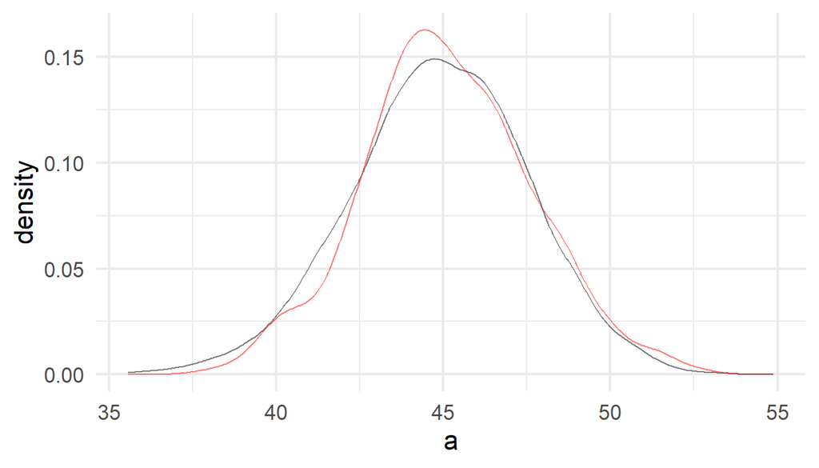

```r
# get posterior sample from stan fitted model
psamp <- as.data.frame(bug_stan_model)
gf_dens(~a, data = psamp) |>
  gf_dens(~beta0, data = quap_bug_post_sample,
          color = 'red',
          inherit = FALSE)
```

- We observe: The two posteriors are pretty similar. If we took more samples from the `stan()` posterior, the posterior shape might smooth out more. And again, we are only comparing these two posteriors in order to verify that we fit the model we thought we fit (ordinarily we would just fit the model in Stan and interpret the results, with no need to compare with `quap()`… and if we really fitted the same model with both and got different results, the Stan results would probably be more reliable).

## Diagnostics

### `n_eff`

- We observe: It’s a little lower than we’d like.
- Action needed? Increasing the number of warmup iterations (which we artificially used a stupidly small number of) might help. We might also reconsider the parameterization and priors of the model. But the total `n_eff` is big, so it’s probably fine.

```r
bug_stan_model2 <- stan(model_code = stan_bug_program,
                       data = stan_bug_data,
                       chains = 6,
                       iter = 4000,
                       warmup = 3000,
                       refresh = 0)
```

[output not shown]

[output not shown]

[output not shown]

[output not shown]

[output not shown]

[output not shown]

[output not shown]

[output not shown]

[output not shown]

[output not shown]

[output not shown]

[output not shown]

```r
bug_stan_model2
```

```
## Inference for Stan model: anon_model.
## 6 chains, each with iter=4000; warmup=3000; thin=1;
## post-warmup draws per chain=1000, total post-warmup draws=6000.
##
##          mean se_mean   sd    2.5%     25%     50%     75%   97.5% n_eff Rhat
## sigma   19.26    0.03 2.10   15.54   17.79   19.11   20.59   23.81  4940    1
## a       44.92    0.03 2.73   39.45   43.12   44.96   46.80   50.13  6389    1
## b        8.99    0.04 2.66    3.87    7.20    8.90   10.76   14.39  5694    1
## c       11.47    0.04 3.24    5.33    9.25   11.43   13.62   17.98  5194    1
## d       -3.52    0.05 3.51  -10.62   -5.83   -3.44   -1.13    3.19  5034    1
## lp__  -178.75    0.03 1.66 -182.82 -179.60 -178.42 -177.53 -176.56  2618    1
##
## Samples were drawn using NUTS(diag_e) at Mon Jun  3 13:26:44 2024.
## For each parameter, n_eff is a crude measure of effective sample size,
## and Rhat is the potential scale reduction factor on split chains (at
## convergence, Rhat=1).
```

### $\hat{R}$

- We observe: All 1s = good
- Action needed? None

## Warning: Divergent Transitions?

- We observe: No such warnings!
- Action needed? None

### Trace Plot

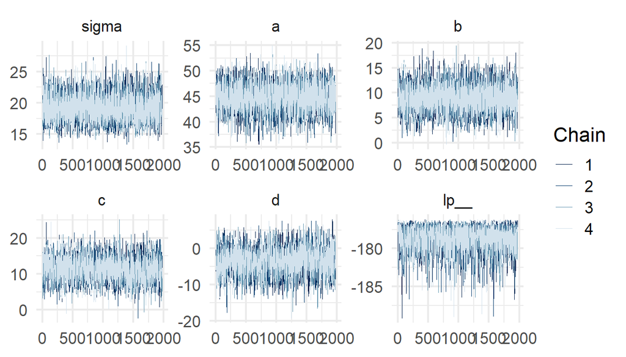

```r
bayesplot::mcmc_trace(bug_stan_model)
```

- We observe: Looks like pretty good mixing
- Action needed? Probably not

### Rank Trace Plot

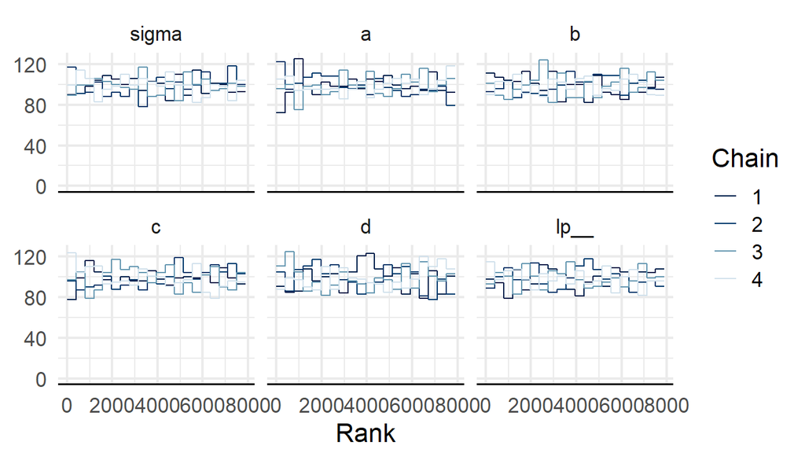

```r
bayesplot::mcmc_rank_overlay(bug_stan_model)
```

- We observe: Rank histogram for each chain looks relatively uniform so that’s ok
- Action needed? Probably none

# Regression with Interacting Categorical Predictors

We’re fitting a model to the `Wines2012` data from the `rethinking` package, with 2 *interacting* categorical predictors.

(If they *were not* interacting, we’d likely formulate the model with two separate categorical predictors instead of one “combo” categorical predictor comprising all combinations of the two categories. Code would look a lot like the code shown here, except with two categorical predictors instead of one!)

## Read in Data

```r
data("Wines2012")
Wines2012 <- Wines2012 |>
  mutate(# make a standardized version of the score variable
    score_std = as.numeric(scale(score)),
    # categorical versions of some variables originally coded 0/1
    wine.origin = ifelse(wine.amer == 1, 'USA', 'Other'),
    judge.nationality = ifelse(judge.amer == 1, 'USA', 'France'),
    # numeric index versions of the same categorical variables
    origin.ix = as.numeric(factor(wine.origin)),
    judge.ix = as.numeric(factor(judge.nationality))
  )

# we'd use this if we wanted the categorical predictors to interact.
# for model without interaction, we won't need it.
Wines2012 <- Wines2012 |>
  mutate(Origin_Judge = interaction(wine.origin, judge.nationality),
         Origin_Judge_ix = as.numeric(Origin_Judge)) |>
  drop_na(Origin_Judge, score_std)

stan_wine_data <- compose_data(Wines2012)

levels(Wines2012$Origin_Judge)
```

```
## [1] "Other.France" "USA.France"   "Other.USA"    "USA.USA"
```

## Original `quap()` model

(for comparison)

```r
wine_model_list <- alist(
  score_std ~ dnorm(mu, sigma),
  mu <- b1[Origin_Judge_ix],
  b1[Origin_Judge_ix] ~ dnorm(0, 0.25),
  sigma ~ dlnorm(0,1)
)

wine_int_model <- quap(
  flist = wine_model_list,
  data = Wines2012
)

precis(wine_int_model, depth = 2)
```

```
##               mean         sd        5.5%      94.5%
## b1[1] -0.042715823 0.14267704 -0.27074129 0.18530964
## b1[2] -0.142568592 0.12343236 -0.33983735 0.05470016
## b1[3]  0.186151913 0.13209068 -0.02495451 0.39725834
## b1[4]  0.009950114 0.11314324 -0.17087464 0.19077487
## sigma  0.982813632 0.05165596  0.90025742 1.06536984
```

```r
wine_stan_program <- 'data {
// number of observations
int<lower=1> n;
// response
vector[n] score_std;
// categorical predictor,"Other.France" or "USA.France" or "Other.USA" or   "USA.USA"
int[n] Origin_Judge;

}
parameters {
// std of response, single continuous value
real<lower=0> sigma;
// vector of 4 numeric values: expected scores for each combo of wine origin & judge origin
vector[4] a;
}

model {
// vector of n values: expected score_std for each observation
vector[n] mu;
// loop over the n cases in the dataset to estimate mu_i values
for (i in 1:n) {
// expected score_std is judge- and wine-origin-specific value
mu[i] = a[Origin_Judge[i]];
}
// THESE PRIORS ARE INTENTIONALLY AWFULLY UNINFORMATIVE
// (WHAT WILL GO WRONG?) Turns out not much -- it is robust
// prior for all four intercepts
a ~ normal(50, 250);
// prior for sigma
sigma ~ lognormal(1,1000);
// defining likelihood in terms of mus and sigma
score_std ~ normal(mu, sigma);
}
'

wine_stan_model <- stan(model_code = wine_stan_program,
                     data = stan_wine_data,
                     chains = 4,
                     # I'm intentionally using too little warmup to try to cause trouble with the diagnostics
                     warmup = 100)
```

[output not shown]

- Note: if you want to use a lognormal distribution for a prior, you need to know what Stan’s function for that distribution is. Remember, there is a reference manual for that: https://mc-stan.org/docs/functions-reference/continuous-distributions.html. We find that Stan uses `lognormal()`.

```r
wine_stan_model
```

[output not shown]

## Warning: Divergent Transitions?

### Trace Plot

```r
bayesplot::mcmc_trace(wine_stan_model)
```

[output not shown]

[output not shown]

### Rank Trace Plot

```r
bayesplot::mcmc_rank_overlay(wine_stan_model)
```

[output not shown]

[output not shown]